# Session 4 — Local Clusters and Hot Spots

Local Moran’s I (LISA) · multiple testing · Getis-Ord Gi* · scan statistic · Lab 4

Community Medicine Workshop

## Where we are

- Session 3: the map **is** clustered (global Moran’s I)
- Today: **where**? Which blocks form hot spots, cold spots or are odd ones out?
- By the end you can:
  - compute **local Moran’s I** and classify **HH, LL, HL, LH** blocks
  - handle **multiple testing**
  - find hot and cold spots with **Getis-Ord Gi***
  - run and read a **spatial scan statistic**

# Topic 1 — Local Moran’s I (LISA)

## One statistic per area

```r
loc <- localmoran(blocks$dengue_per_100k, lw, zero.policy = TRUE)
head(round(loc, 3), 4)
```

```
      Ii   E.Ii Var.Ii   Z.Ii Pr(z != E(Ii))
1 -0.228 -0.001  0.016 -1.773          0.076
2  0.094 -0.007  0.132  0.277          0.781
3 -0.043 -0.052  1.923  0.006          0.995
4  0.403 -0.007  0.140  1.099          0.272
```

| Column | Meaning |
| --- | --- |
| `Ii` | this area’s local I: > 0 similar to neighbours, < 0 unlike them |
| `Z.Ii` | z-score |
| `Pr(z != E(Ii))` | two-sided p-value |

The **average of the local values equals the global I**: the global statistic is the average of the local ones (0.499).

## Cluster types from the quadrant

```r
z <- as.numeric(scale(blocks$dengue_per_100k)); lag_z <- lag.listw(lw, z, zero.policy = TRUE); p <- loc[, "Pr(z != E(Ii))"]
blocks$lisa <- factor(case_when(p >= 0.05 ~ "Not significant", z > 0 & lag_z > 0 ~ "High-High", z < 0 & lag_z < 0 ~ "Low-Low",
                                z > 0 & lag_z < 0 ~ "High-Low", TRUE ~ "Low-High"),
                      levels = c("High-High", "Low-Low", "High-Low", "Low-High", "Not significant"))
table(blocks$lisa)
```

```
      High-High         Low-Low        High-Low        Low-High Not significant
             11              10               1               0              57
```

```r
cols <- c("High-High" = "#d7191c", "Low-Low" = "#2c7bb6", "High-Low" = "#fdae61", "Low-High" = "#abd9e9", "Not significant" = "grey90")
ggplot(blocks) + geom_sf(aes(fill = lisa), colour = "white") + scale_fill_manual(values = cols, drop = FALSE, name = NULL) +
  labs(title = "LISA cluster map (p < 0.05, unadjusted)")
```

- **High-High:** hot spot. **Low-Low:** cold spot
- **High-Low / Low-High:** spatial **outliers**, unlike their neighbours: check the data first
- Here: a hot spot in the **south-east**, a cold spot in the **north-west**, one outlier

## Cluster types from the quadrant

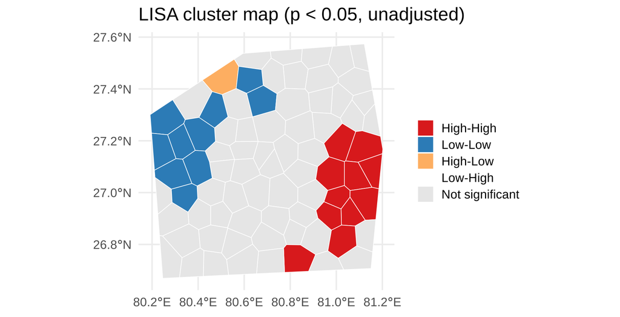

## Multiple testing

You ran **79 tests**: at 5%, about 4 blocks look significant by chance, and the tests are **correlated** (neighbours share neighbours).

```r
c(unadjusted = sum(p < 0.05), fdr = sum(p.adjust(p, "fdr") < 0.05), bonferroni = sum(p.adjust(p, "bonferroni") < 0.05))
```

```
unadjusted        fdr bonferroni
        22         13          3
```

- **FDR** (Benjamini-Hochberg) is a sensible default; **Bonferroni** is the strictest
- Treat LISA as **exploratory**: it tells you where to look
- The analytic p-values assume near-normal data; `localmoran_perm()` gives permutation p-values for skewed rates

# Topic 2 — Getis-Ord Gi*

## Hot and cold spots directly

Gi* sums the values of an area **and its neighbours** (the `*` includes the area itself) and turns the sum into a **z-score**.

```r
lw_self <- nb2listw(include.self(nb), style = "B", zero.policy = TRUE)
blocks$gi <- as.numeric(localG(blocks$dengue_per_100k, lw_self, zero.policy = TRUE))
blocks$gi_class <- cut(blocks$gi, c(-Inf, -2.58, -1.96, -1.65, 1.65, 1.96, 2.58, Inf),
                       labels = c("Cold 99%", "Cold 95%", "Cold 90%", "Not significant", "Hot 90%", "Hot 95%", "Hot 99%"))
table(blocks$gi_class)
```

```
       Cold 99%        Cold 95%        Cold 90% Not significant         Hot 90%
              7               6               3              46               5
        Hot 95%         Hot 99%
              1              11
```

```r
ggplot(blocks) + geom_sf(aes(fill = gi_class), colour = "white") +
  scale_fill_manual(values = c("Cold 99%" = "#2166ac", "Cold 95%" = "#67a9cf", "Cold 90%" = "#d1e5f0", "Not significant" = "grey92",
                               "Hot 90%" = "#fddbc7", "Hot 95%" = "#ef8a62", "Hot 99%" = "#b2182b"), drop = FALSE, name = NULL) +
  labs(title = "Getis-Ord Gi* hot and cold spots")
```

## Hot and cold spots directly

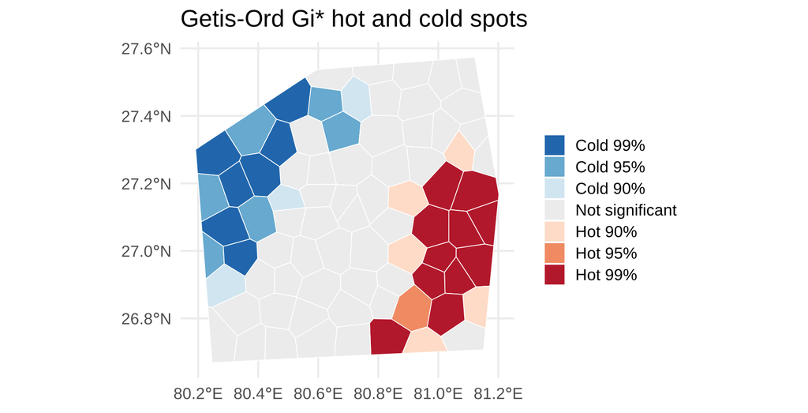

## Gi* or LISA?

**LISA** finds areas **similar** to their neighbours (hot or cold) **and outliers**.

**Gi*** finds where **high** (or low) **sums concentrate**: it separates hot from cold directly, but does not flag outliers.

Both run one test per area: apply the same **multiple-testing** caution.

# Topic 3 — The scan statistic

## Kulldorff’s circles

Slide **circles of many sizes** over the map; for each ask whether it holds **more cases than expected from the population**. Reports the **most likely cluster**, its relative risk and a Monte Carlo p-value. Uses **counts and population** (Poisson), so no rates are needed.

```r
cen_km <- st_coordinates(st_centroid(st_transform(blocks, 32644))) / 1000
set.seed(5)
sc <- scan.test(coords = cen_km, cases = blocks$dengue_cases, pop = blocks$population, nsim = 499, alpha = 0.05)
summary(sc)
```

```
  nregions max_dist cases    ex  rr stat     p
1       34     81.2   627 477.7 1.8 42.7 0.002
```

- Read: **blocks in the cluster**, **observed vs expected** cases, **relative risk**, **p-value**
- The **maximum window** (default 50% of the population) changes what you find; choose it deliberately
- Report the model (Poisson), the window, the number of simulations

## Which local tool?

| Question | Tool |
| --- | --- |
| Which areas are clusters or outliers? | **local Moran (LISA)** |
| Where are hot and cold spots? | **Getis-Ord Gi*** |
| Is there one most likely cluster, from counts and population? | **scan statistic** |
| Are the results robust? | other weights; adjusted p; compare methods |

## 🔧 Switch to R — Lab 4

**File:** `gis-workshop/labs/lab4_local.R`

- `localmoran()` · classify HH / LL / HL / LH · map them
- `p.adjust()` · `localG()` with `include.self()`
- `scan.test()` and which blocks fall in the cluster

**Time:** 40 minutes · answer the Q questions in the comments

## Self-check quiz (1/5)

A block is classed High-Low (significant) in a LISA map. What does that mean?

- It has a low value and is surrounded by high-value neighbours
- It is part of a hot spot of several high-value blocks
- It has a high value but is surrounded by low-value neighbours
- Its p-value is too large for it to be classified

## Self-check quiz (2/5)

Why should LISA p-values be adjusted or treated cautiously?

- Local Moran’s I can be calculated for a half of the areas at most
- Many tests are run, and neighbouring tests are correlated
- The p-values from localmoran() are always far too large to be used
- LISA gives a single p-value for the whole map, not for each area

## Self-check quiz (3/5)

How are the local Moran values related to the global Moran’s I?

- The global I is the largest of the local values
- They are unrelated statistics answering different questions
- The global I is the average of the local values
- The global I is the sum of the squared local values

## Self-check quiz (4/5)

What does Getis-Ord Gi* give that local Moran’s I does not?

- A p-value for every block without any assumptions
- A way to avoid choosing a spatial weights matrix
- A correction for differences in population size
- A direct separation of hot spots from cold spots

## Self-check quiz (5/5)

What does the Kulldorff scan statistic report as its main result?

- The most likely cluster, with its relative risk and p-value
- A Moran’s I value for each one of the circles that was scanned
- The spatial lag of each of the blocks in the whole study area
- The best neighbour definition for the spatial weights matrix used

## Score and take-home

**Your score:**

- **LISA** gives each area a statistic, a p-value and a cluster type (HH, LL, HL, LH)
- Many tests: **adjust** (FDR) and treat as **exploratory**
- **Gi*** separates **hot** from **cold** spots
- The **scan statistic** finds the **most likely cluster** from counts and population

**Next:** Session 5: spatial regression and reporting